# Exploratory Subgroup Identification with ForestSearch

German Breast Cancer Study Group (GBSG) Analysis: Cox and Poisson Rate Model Comparison

Author

Larry F. León

Published

April 12, 2026

# 1 Introduction

This vignette demonstrates the **ForestSearch** methodology for exploratory subgroup identification in survival analysis, as described in León et al. (2024) *Statistics in Medicine*.

## 1.1 Motivation

In clinical trials, particularly oncology, subgroup analyses are essential for:

- Evaluating treatment effect consistency across patient populations
- Identifying subgroups where treatment may be detrimental (harm)
- Characterizing subgroups with enhanced benefit
- Informing regulatory decisions and clinical practice

While prespecified subgroups provide stronger evidence, important subgroups based on patient characteristics may not be anticipated. ForestSearch provides a principled approach to **exploratory** subgroup identification with proper statistical inference.

## 1.2 Methodology Overview

ForestSearch identifies subgroups through:

1. **Candidate factor selection**: Using LASSO and/or Generalized Random Forests (GRF)
2. **Exhaustive subgroup search**: Evaluating all combinations up to `maxk` factors
3. **Consistency-based selection**: Applying splitting consistency criteria
4. **Bootstrap bias correction**: Adjusting for selection-induced optimism
5. **Cross-validation**: Assessing algorithm stability

The key innovation is the **splitting consistency criterion**: a subgroup is considered “consistent with harm” if, when randomly split 50/50 many times, both halves consistently show hazard ratios ≥ 1.0 (for example if 1.0 represents a meaningful “harm threshold”).

# 2 Setup

## 2.1 Load Required Packages

```r
library(forestsearch)
library(survival)
library(data.table)
library(ggplot2)
library(gt)
library(grf)
library(policytree)
library(doFuture)
# Optional packages for enhanced output
library(patchwork)
library(weightedsurv)

# Set ggplot theme
theme_set(theme_minimal(base_size = 12))
```

## 2.2 Analysis Parameters

```r
# ─── Shared parameters ───────────────────────────────────────────────────
n_cores <- 120
n_cores_total <- parallel::detectCores()
cat("Using", n_cores, "of", n_cores_total, "total cores\n")
```

```
#> Using 120 of 128 total cores
```

```r
confounders.name <- c("age", "meno", "size", "grade3", "nodes", "pgr", "er")
id.name    <- "id"

# ─── Cox parameters ──────────────────────────────────────────────────────
cox_outcome.name <- "time_months"
cox_event.name   <- "status"
cox_treat.name   <- "hormon"

# ─── ForestSearch tuning (shared across Cox and Poisson) ─────────────────
fs_hr.threshold            <- 1.25
fs_hr.consistency          <- 1.0
fs_pconsistency.threshold  <- 0.80
fs_stop_threshold          <- 0.80
fs_maxk                    <- 2
fs_n.min                   <- 60
fs_d0.min                  <- 12
fs_d1.min                  <- 12
fs_splits                  <- 400
fs_max_subgroups_search    <- 3

# ─── Bootstrap / CV ──────────────────────────────────────────────────────
NB    <- 1000    # Bootstrap iterations (use 500–2000 for production)
Ksims <- 50    # K-fold CV iterations (use ≥ 50 for production)

# ─── GRF parameters (shared across Cox and Poisson) ─────────────────────
grf_tune           <- TRUE  # cross-validated GRF hyperparameter tuning
grf_vi_min         <- -0.2   # GRF variable importance threshold
grf_dmin_cox       <- 12     # min RMST difference for Cox GRF (months)
grf_dmin_pois      <- 0.0    # min CATE difference for Poisson GRF
grf_maxdepth       <- 2L     # max policy tree depth

# ─── Poisson-specific parameters ─────────────────────────────────────────
pois_outcome.name   <- "status"         # event indicator (0/1 count)
pois_offset.name    <- "time_months"    # person-time offset
pois_treat.name     <- "hormon"
pois_effect_measure <- "IRR"
```

# 3 Data: German Breast Cancer Study Group Trial

## 3.1 Study Background

The GBSG trial evaluated hormonal treatment (tamoxifen) versus chemotherapy in node-positive breast cancer patients. Key characteristics:

- **Sample size**: N = 686
- **Outcome**: Recurrence-free survival time
- **Censoring rate**: ~56%
- **Treatment**: Hormonal therapy (tamoxifen) vs. chemotherapy

## 3.2 Data Preparation

```r
# Load GBSG data (included in forestsearch package)
df.analysis <- gbsg

# Prepare analysis variables
df.analysis <- within(df.analysis, {
  id <- seq_len(nrow(df.analysis))
  time_months <- rfstime / 30.4375
  grade3 <- ifelse(grade == "3", 1, 0)
  treat <- hormon
})

# Display data structure
cat("Sample size:", nrow(df.analysis), "\n")
```

```
#> Sample size: 686
```

```r
cat("Events:", sum(df.analysis[[cox_event.name]]),
    sprintf("(%.1f%%)\n", 100 * mean(df.analysis[[cox_event.name]])))
```

```
#> Events: 299 (43.6%)
```

```r
cat("Baseline factors:", paste(confounders.name, collapse = ", "), "\n")
```

```
#> Baseline factors: age, meno, size, grade3, nodes, pgr, er
```

## 3.3 Baseline Characteristics

```r
create_summary_table(
  data = df.analysis,
  treat_var = cox_treat.name,
  table_title = "GBSG Baseline Characteristics by Treatment Arm",
  vars_continuous = c("age", "nodes", "size", "er", "pgr"),
  vars_categorical = c("grade", "meno"),
  font_size = 12
)
```

GBSG Baseline Characteristics by Treatment Arm

| Characteristic |  | Control (n=440) | Treatment (n=246) | P-value<sup>1</sup> | SMD<sup>2</sup> |
| --- | --- | --- | --- | --- | --- |
| age | Mean (SD) | 51.1 (10.0) | 56.6 (9.4) | <0.001 | 0.57 |
| nodes | Mean (SD) | 4.9 (5.6) | 5.1 (5.3) | 0.665 | 0.03 |
| size | Mean (SD) | 29.6 (14.4) | 28.8 (14.1) | 0.470 | 0.06 |
| er | Mean (SD) | 79.7 (124.2) | 125.8 (191.1) | <0.001 | 0.30 |
| pgr | Mean (SD) | 102.0 (170.0) | 124.3 (249.7) | 0.213 | 0.11 |
| grade |  |  |  | 0.273 | 0.06 |
|  | 1 | 48 (10.9%) | 33 (13.4%) |  |  |
|  | 2 | 281 (63.9%) | 163 (66.3%) |  |  |
|  | 3 | 111 (25.2%) | 50 (20.3%) |  |  |
| meno |  | 209 (47.5%) | 187 (76.0%) | <0.001 | 0.61 |

<sup>1</sup> P-values: t-test for continuous, chi-square/Fisher's exact for categorical/binary variables  
<sup>2</sup> SMD = Standardized mean difference (Cohen's d for continuous, Cramer's V for categorical)

## 3.4 Kaplan-Meier Analysis (ITT Population)

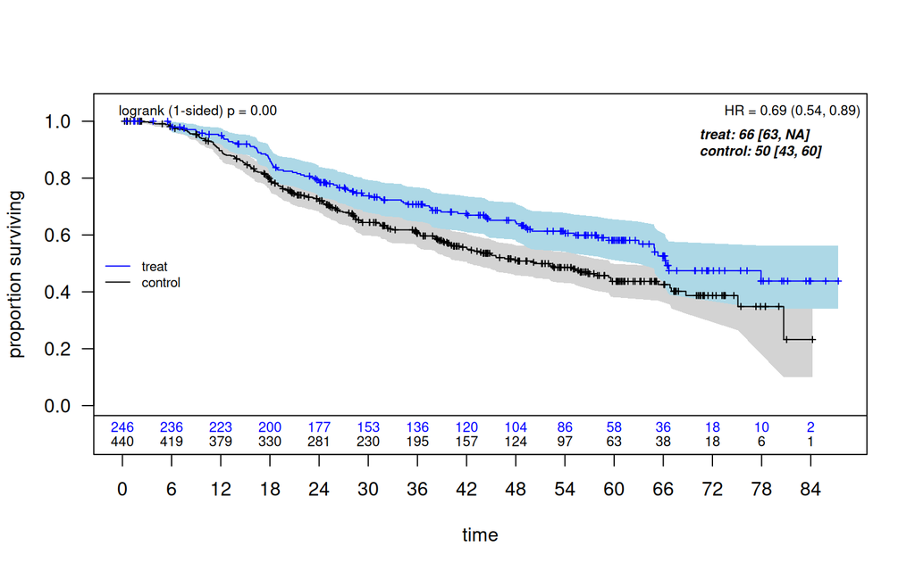

```r
# Prepare counting process data for KM plot
dfcount <- df_counting(
  df = df.analysis,
  by.risk = 6,
  tte.name = cox_outcome.name,
  event.name = cox_event.name,
  treat.name = cox_treat.name
)

# Plot with confidence intervals and log-rank test
plot_weighted_km(
  dfcount,
  conf.int = TRUE,
  show.logrank = TRUE,
  ymax = 1.05,
  xmed.fraction = 0.775,
  ymed.offset = 0.125
)
```

The ITT Cox hazard ratio estimate is approximately 0.69 (95% CI: 0.54, 0.89), suggesting an overall benefit for hormonal therapy.

# 4 Preliminary Analysis: Generalized Random Forests

Before running ForestSearch, we can use GRF to explore potential treatment effect heterogeneity and identify candidate factors.

```r
t0 <- proc.time()

grf_est <- grf.subg.harm.survival(
  data = df.analysis,
  confounders.name = confounders.name,
  outcome.name = cox_outcome.name,
  event.name = cox_event.name,
  id.name = id.name,
  treat.name = cox_treat.name,
  maxdepth = grf_maxdepth,
  n.min = fs_n.min,
  dmin.grf = grf_dmin_cox,
  frac.tau = 0.6,
  details = TRUE,
  return_selected_cuts_only = FALSE,
  tune_grf = grf_tune
)
```

```
#> tau, maxdepth = 46.75811 2
#>    leaf.node control.mean control.size control.se depth
#> 1          2         6.49        82.00       3.34     1
#> 2          3        -4.10       604.00       1.06     1
#> 11         4        -7.90       112.00       2.81     2
#> 21         5         3.86       177.00       1.87     2
#> 4          7        -5.89       356.00       1.33     2
#>
#> Selected subgroup:
#>   leaf.node control.mean control.size control.se depth
#> 1         2         6.49        82.00       3.34     1
#>
#> GRF subgroup found
#> Terminating node at max.diff (sg.harm.id):
#> [1] "er <= 0"
#>
#> All splits (from all trees):
#> [1] "er <= 0"   "age <= 50" "age <= 43"
```

```r
timings$grf <- (proc.time() - t0)["elapsed"]
```

```r
# Display policy trees
# leaf1 = recommend control, leaf2 = recommend treatment
oldpar <- par(mfrow = c(1, 2))
plot(grf_est$tree1, leaf.labels = c("Control", "Treat"), main = "Depth 1")
```

[interactive chart not shown]

```r
plot(grf_est$tree2, leaf.labels = c("Control", "Treat"), main = "Depth 2")
```

[interactive chart not shown]

```r
par(oldpar)
```

GRF identifies estrogen receptor status (ER) as a key factor, with ER ≤ 0 suggesting potential harm from hormonal therapy.

# 5 Part I: Cox Proportional Hazards Analysis

## 5.1 Parallel Processing Configuration

ForestSearch supports parallel processing for computationally intensive operations (bootstrap, cross-validation).

```r
cat("Using", n_cores, "of", n_cores_total, "total cores for parallel processing")
```

```
#> Using 120 of 128 total cores for parallel processing
```

## 5.2 Running ForestSearch (Cox)

ForestSearch performs an exhaustive search over candidate subgroup combinations with up to `maxk` factors. Key parameters:

[output not shown]

```
#>
#> [forestsearch] Subgroup Identification Configuration
#>   Outcome type:   survival (Cox PH)
#>   Effect measure: HR (hazard ratio)
#>   Scale:          log (ratio)
#>
#>   Screening:      HR >= 1.25  (log: 0.2231)
#>   Consistency:    HR >= 1.00  (log: 0.0000)
#>   Consistency rate threshold: 80%
#>
#>   Interpretation:
#>     Candidates: subgroup hazard ratio >= 1.25
#>     Splits:     each split HR >= 1.00
```

```
#>   Search Alignment Diagnostic
```

```
#>
#>   Outcome:    time_months (survival)
```

```
#>   Treatment:  hormon
```

```
#>   Measure:    Hazard Ratio (HR)
```

```
#>
#>   ForestSearch searches for:
#>     Subgroups where hormon increases the event hazard
#>     (HR >= threshold in the candidate subgroup)
```

```
#>
#>   Thresholds:
#>     Screening: HR >= 1.250 in the candidate subgroup
#>     Consistency: HR >= 1.000 in each bootstrap split
```

```
#>
#>   Variable screening:
```

```
#>     LASSO: LASSO screening uses glmnet with family = "Cox (coxnet)".
#>     Variables with non-zero coefficients are retained.
```

```
#>     GRF:   causal_survival_forest() estimates treatment effect on
#>     survival probability. Positive CATE = treatment increases
#>     survival = treatment HELPS (events assumed adverse).
```

```
#>
#>   No alignment concerns detected.
```

```
#> GRF subgroup: er <= 0
#> GRF cuts identified: 1
#>   Cuts: er <= 0
#> Cox-LASSO selected: 4 of 7 candidate factors
#>   Omitted: age, meno, er
#> Candidate factors: 14
#>  [1] "er <= 0"      "size <= 29.3" "size <= 25"   "size <= 20"   "size <= 35"
#>  [6] "nodes <= 5"   "nodes <= 3"   "nodes <= 1"   "nodes <= 7"   "pgr <= 110"
#> [11] "pgr <= 32.5"  "pgr <= 7"     "pgr <= 131.8" "grade3"
#> Number of possible configurations (<= maxk): maxk = 2 , # combinations = 406
#> Events criteria: control >= 12 , treatment >= 12
#> Sample size criteria: n >= 60
#> Subgroup search completed in 0.02 minutes
#>
#> --- Filtering Summary ---
#>   Combinations evaluated: 406
#>   Passed variance check: 374
#>   Passed prevalence (>= 0.025 ): 374
#>   Passed redundancy check: 354
#>   Passed event counts (d0>= 12 , d1>= 12 ): 250
#>   Passed sample size (n>= 60 ): 247
#>   Cox model fit successfully: 247
#>   Passed HR threshold (>= 1.25 ): 7
#> -------------------------
#>
#> Found 7 subgroup candidate(s)
#> # of candidate subgroups (meeting all criteria) = 7
#> # of unique initial candidates: 7
#> # Restricting to top stop_Kgroups = 3
#> # of candidates to evaluate: 3
#> # Early stop threshold: 0.8
#>
#> ================================================================================
#> TOP 3 CANDIDATE SUBGROUPS FOR CONSISTENCY EVALUATION
#> Sorted by: hr
#> ================================================================================
#>
#> Rank   HR        N       Events  K    Subgroup Definition
#> --------------------------------------------------------------------------------
#> 1      2.537     61      34      2    {er <= 0} & {size <= 35}
#> 2      2.222     75      41      2    {er <= 0} & {pgr <= 32.5}
#> 3      2.054     61      35      2    {er <= 0} & !{size <= 20}
#> --------------------------------------------------------------------------------
```

```
#> Parallel plan: multisession with 120 workers.
```

```
#> Parallel config: workers = 120 , batch_size = 1
#> Batch 1 / 3 : candidates 1 - 1
#>
#> ==================================================
#> EARLY STOP TRIGGERED (batch 1 )
#>   Candidate: 1 of 3
#>   Pcons: 0.97 >= 0.8
#> ==================================================
#>
#> Evaluated 1 of 3 candidates (early stop)
#> 1 subgroups passed consistency threshold
```

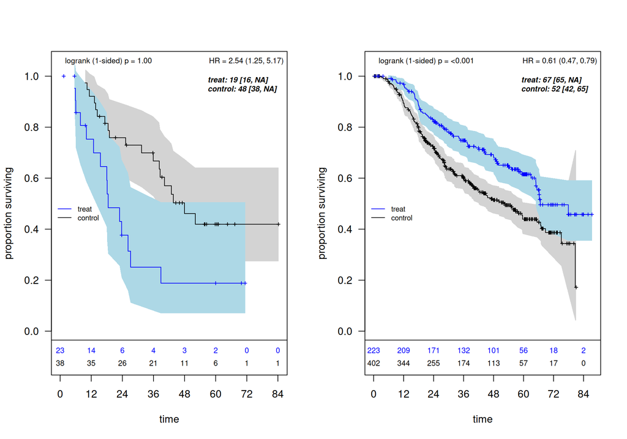

```
#> *** Subgroup found: {er <= 0} {size <= 35}
#> % consistency criteria met= 0.97
#> SG focus = hr
#> Seconds and minutes forestsearch overall = 6.484 0.1081
#> Consistency algorithm used: twostage
#> Subgroup identified: {er <= 0} & {size <= 35}
```

```r
t0 <- proc.time()

fs_cox <- forestsearch(
  df.analysis,
  confounders.name = confounders.name,
  outcome.name = cox_outcome.name,
  treat.name = cox_treat.name,
  event.name = cox_event.name,
  id.name = id.name,
  # Threshold parameters (per León et al. 2024)
  hr.threshold = fs_hr.threshold,
  hr.consistency = fs_hr.consistency,
  pconsistency.threshold = fs_pconsistency.threshold,
  stop_threshold = fs_stop_threshold,
  # Search configuration
  sg_focus = "hr",
  max_subgroups_search = fs_max_subgroups_search,
  use_twostage = TRUE,
  # Factor selection
  use_grf = TRUE,
  return_selected_cuts_only = TRUE,
  use_lasso = TRUE,
  cut_type = "default",
  # Subgroup constraints
  maxk = fs_maxk,
  n.min = fs_n.min,
  d0.min = fs_d0.min,
  d1.min = fs_d1.min,
  # Consistency evaluation
  fs.splits = fs_splits,
  # Parallel processing
  parallel_args = list(
    plan = "multisession",
    workers = n_cores,
    show_message = TRUE
  ),
  # Output options
  showten_subgroups = TRUE,
  details = TRUE,
  plot.sg = TRUE,
  vi.grf.min = grf_vi_min,
  tune_grf = grf_tune
)
```

```r
plan("sequential")
timings$cox_fs <- (proc.time() - t0)["elapsed"]

cat("\nForestSearch (Cox) completed in",
    round(timings$cox_fs, 1), "seconds\n")
```

```
#>
#> ForestSearch (Cox) completed in 6.5 seconds
```

## 5.3 Cox Results

### 5.3.1 Identified Subgroups

```r
# Generate results tables
cox_tabs <- sg_tables(fs_cox, ndecimals = 3, which_df = "est")

# Display top subgroups meeting criteria
cox_tabs$sg10_out
```

**Identified Subgroups**

Two-factor subgroups (maxk=2)

| Factor 1 | Factor 2 | N | Events | E<sub>1</sub> | HR | P<sub>cons</sub> |
| --- | --- | --- | --- | --- | --- | --- |
| {er <= 0} | {size <= 35} | 61 | 34 | 15 | 2.537 | 0.970 |

**Search Configuration:** Single-factor candidates (L) = 28; Maximum combinations evaluated = 406; Search depth (maxk) = 2  
**Search Results:** Candidate subgroups found = 7; Maximum HR estimate = 2.54  
**Note:** E<sub>1</sub> = events in treatment arm; P<sub>cons</sub> = consistency proportion

### 5.3.2 Treatment Effect Estimates

```r
cox_tabs$tab_estimates
```

**Treatment Effect Estimates**

Training data estimates

| Subgroup | n | n1 | events | m1 | m0 | RMST | HR (95% CI) |
| --- | --- | --- | --- | --- | --- | --- | --- |
| ITT | 686 (100.0%) | 246 (35.9%) | 299 (43.6%) | 66.3 | 50.2 | 7.8 | 0.69 (0.54, 0.89) |
| Questionable<sup>1</sup> | 61 (8.9%) | 23 (37.7%) | 34 (55.7%) | 18.5 | 48 | -19 | 2.54 (1.25, 5.17) |
| Recommend | 625 (91.1%) | 223 (35.7%) | 265 (42.4%) | 66.7 | 52.2 | 9.6 | 0.61 (0.47, 0.79) |

<sup>1</sup> **Identified subgroup** : {er <= 0} & {size <= 35}

### 5.3.3 Identified Subgroup Definition

```r
cat("Identified subgroup (H):", paste(fs_cox$sg.harm, collapse = " & "), "\n")
```

```
#> Identified subgroup (H): {er <= 0} & {size <= 35}
```

```r
cat("Subgroup size:", sum(fs_cox$df.est$treat.recommend == 0),
    sprintf("(%.1f%% of ITT)\n",
            100 * mean(fs_cox$df.est$treat.recommend == 0)))
```

```
#> Subgroup size: 61 (8.9% of ITT)
```

## 5.4 Cox Bootstrap Bias Correction

```r
t0 <- proc.time()

fs_cox_bc <- forestsearch_bootstrap_dofuture(
  fs.est = fs_cox,
  nb_boots = NB,
  show_three = FALSE,
  details = FALSE,
  parallel_args = list(
    plan = "multisession",
    workers = n_cores,
    show_message = TRUE
  )
)
```

```
#> Bootstrap parallel config: Using user-provided settings
```

```
#> System max cores available: 128
```

```
#> Bootstrap will use: 120 workers with 'multisession' plan
```

```
#> Parallel plan: multisession with 120 workers.
```

```
#> Bootstrap iteration 1/1000
```

```
#> Bootstrap iteration 10/1000
```

```
#> Bootstrap iteration 50/1000
```

```
#> Bootstrap iteration 100/1000
```

```
#> Bootstrap iteration 250/1000
```

```
#>   Bootstrap 255: Low events in subgroup H (Control=23, Treat=4)
```

```
#> Bootstrap iteration 500/1000
```

```
#> Bootstrap iteration 750/1000
```

```
#>   Bootstrap 974: Low events in subgroup H (Control=15, Treat=3)
```

```
#> Bootstrap iteration 1000/1000
```

```r
plan("sequential")
timings$cox_bootstrap <- (proc.time() - t0)["elapsed"]

cat("\nBootstrap completed in",
    round(timings$cox_bootstrap / 60, 1), "minutes\n")
```

```
#>
#> Bootstrap completed in 2.1 minutes
```

### 5.4.1 Bootstrap Summary

```r
cox_summaries <- summarize_bootstrap_results(
  sgharm = fs_cox$sg.harm,
  boot_results = fs_cox_bc,
  create_plots = TRUE,
  est.scale = "hr"
)
```

```
#>
#> ===============================================================
#>            BOOTSTRAP ANALYSIS SUMMARY
#> ===============================================================
#>
#> IDENTIFIED SUBGROUP:
#> -------------------------------------------------------------
#>   H: {er <= 0} & {size <= 35}
#>
#> BOOTSTRAP SUCCESS METRICS:
#> -------------------------------------------------------------
#>   Total iterations:              1000
#>   Successful subgroup ID:        923 (92.3%)
#>   Failed to find subgroup:       77 (7.7%)
#>
#> TIMING ANALYSIS:
#> -------------------------------------------------------------
#> Overall:
#>   Total bootstrap time:          1.96 minutes (0.03 hours)
#>   Average per iteration:         0.00 min (0.1 sec)
```

```r
cox_summaries$table
```

**Treatment Effect by Subgroup**

Bootstrap bias-corrected estimates (1000 iterations)

| Subgroup | Sample Size N | Sample Size N<sub>T</sub> | Sample Size Events | Survival Med<sub>T</sub> | Survival Med<sub>C</sub> | Survival RMST<sub>d</sub> | Treatment Effect HR (95% CI)†<sup>1</sup> | Treatment Effect HR‡ (95% CI)<sup>2</sup> |
| --- | --- | --- | --- | --- | --- | --- | --- | --- |
| Qstnbl<sup>3</sup> | 61 (8.9%) | 23 (37.7%) | 34 (55.7%) | 18.5 | 48 | -19 | 2.54 (1.25, 5.17) | 1.95 (0.89,4.26) |
| Recmnd | 625 (91.1%) | 223 (35.7%) | 265 (42.4%) | 66.7 | 52.2 | 9.6 | 0.61 (0.47, 0.79) | 0.63 (0.43,0.91) |

<sup>1</sup> **Unadjusted HR**: Standard Cox regression hazard ratio with robust standard errors  
<sup>2</sup> **Bias-corrected HR**: Bootstrap-adjusted estimate using infinitesimal jackknife method (1000 iterations). Corrects for optimism in subgroup selection.  
<sup>3</sup> **Identified subgroup**: {er <= 0} & {size <= 35}  
*Note*: Med = Median survival time (months). RMST<sub>d</sub> = Restricted mean survival time difference. Subgroup identified in 92.3% of bootstrap samples.

### 5.4.2 Kaplan-Meier by Identified Subgroups

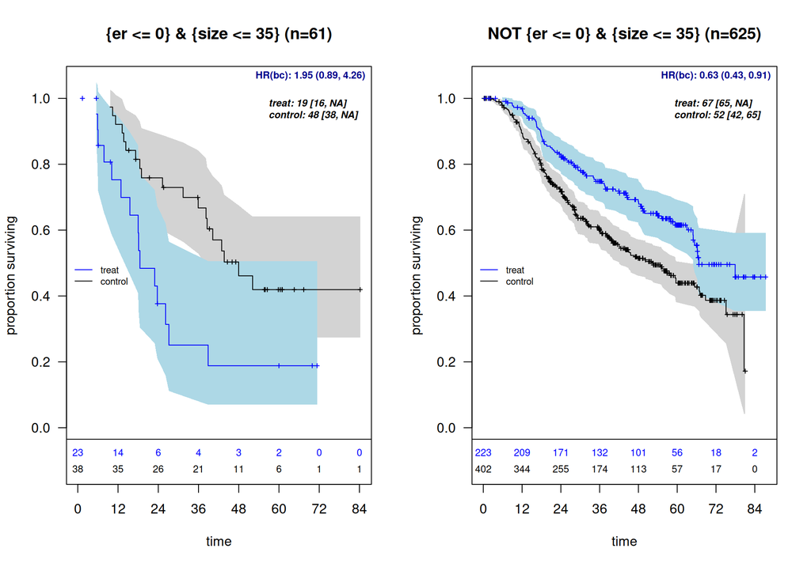

Kaplan-Meier survival curves by identified subgroup (Cox analysis)

```r
km_result_cox <- plot_sg_weighted_km(
  fs.est = fs_cox,
  outcome.name = cox_outcome.name,
  event.name = cox_event.name,
  treat.name = cox_treat.name,
  show.logrank = FALSE,
  conf.int = TRUE,
  by.risk = 12,
  show.cox = FALSE, show.cox.bc = TRUE,
  fs_bc = fs_cox_bc,
  hr_bc_position = "topright"
)
```

**Note**

**Note:** Identified subgroup: {er <= 0} & {size <= 35}. HR(bc) = bootstrap bias-corrected hazard ratio. Medians [95% CI] for arms are un-adjusted.

### 5.4.3 Event Count Summary

```r
event_summary_cox <- summarize_bootstrap_events(fs_cox_bc, threshold = 15)
```

```
#>
#> === Bootstrap Event Count Summary ===
#> Total bootstrap iterations: 1000
#> Event threshold: <15 events
#>
#> ORIGINAL Subgroup H on BOOTSTRAP samples:
#>   Control arm <15 events: 0 (0.0%)
#>   Treatment arm <15 events: 0 (0.0%)
#>   Either arm <15 events: 0 (0.0%)
#>
#> ORIGINAL Subgroup Hc on BOOTSTRAP samples:
#>   Control arm <15 events: 0 (0.0%)
#>   Treatment arm <15 events: 0 (0.0%)
#>   Either arm <15 events: 0 (0.0%)
#>
#> NEW Subgroups found: 923 (92.3%)
#>
#> NEW Subgroup H* on ORIGINAL data:
#>   Control arm <15 events: 91 (9.9% of successful)
#>   Treatment arm <15 events: 286 (31.0% of successful)
#>   Either arm <15 events: 358 (38.8% of successful)
#>
#> NEW Subgroup Hc* on ORIGINAL data:
#>   Control arm <15 events: 0 (0.0% of successful)
#>   Treatment arm <15 events: 0 (0.0% of successful)
#>   Either arm <15 events: 0 (0.0% of successful)
```

### 5.4.4 Bootstrap Diagnostics

```r
cox_summaries$diagnostics_table_gt
```

**Bootstrap Diagnostics Summary**

Analysis of 1000 bootstrap iterations

| Category | Metric | Value |
| --- | --- | --- |
| Success Rate | Total iterations | 1000 |
|  | Successful | 923 (92.3%) |
|  | Failed | 77 (7.7%) |
|  | Success rating | Excellent |
| Subgroup H (Questionable) | Observed HR | 2.537 |
|  | Bias-corrected HR | 1.946 |
|  | Bootstrap CV (%) | 75.4% |
|  | N estimates | 923 |
| Subgroup Hc (Recommend) | Observed HR | 0.608 |
|  | Bias-corrected HR | 0.628 |
|  | Bootstrap CV (%) | 46.5% |
|  | N estimates | 923 |

### 5.4.5 Subgroup Agreement

```r
if (!is.null(cox_summaries$subgroup_summary$original_agreement)) {
  cox_summaries$subgroup_summary$original_agreement
}
```

```
#>                             Metric                    Value
#>                             <char>                   <char>
#> 1:      Total bootstrap iterations                     1000
#> 2:           Successful iterations                      923
#> 3: Failed iterations (no subgroup)                       77
#> 4:
#> 5:    Original subgroup definition {er <= 0} & {size <= 35}
#> 6:       Exact match with original                50 (5.4%)
#> 7:         Different from original              873 (94.6%)
#> 8:   Partial match (shared factor)              296 (32.1%)
```

```r
if (!is.null(cox_summaries$subgroup_summary$factor_presence)) {
  cox_summaries$subgroup_summary$factor_presence
}
```

```
#>   Rank Factor Count  Percent
#> 2    1     er   500 54.17118
#> 6    2    pgr   411 44.52871
#> 7    3   size   276 29.90249
#> 1    4    age   194 21.01842
#> 3    5 grade3   188 20.36836
#> 5    6  nodes   161 17.44312
#> 4    7   meno    76  8.23402
```

### 5.4.6 Bootstrap Distributions

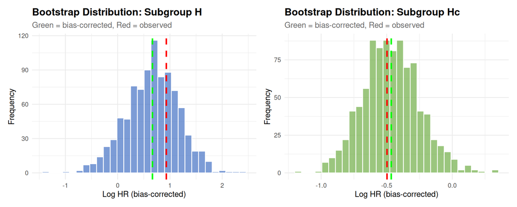

```r
if (!is.null(cox_summaries$plots)) {
  cox_summaries$plots$H_distribution + cox_summaries$plots$Hc_distribution
}
```

## 5.5 Cox Cross-Validation

### 5.5.1 K-Fold Cross-Validation

```r
t0 <- proc.time()

fs_cox_kfold <- forestsearch_tenfold(
  fs.est = fs_cox,
  sims = Ksims,
  Kfolds = 10,
  details = FALSE,
  parallel_args = list(
    plan = "multisession",
    workers = n_cores,
    show_message = FALSE
  )
)

plan("sequential")
timings$cox_kfold <- (proc.time() - t0)["elapsed"]
cox_metrics <- cv_metrics_tables(fs_cox_kfold)
cox_metrics
```

**Cross-Validation Metrics**

Subgroup: Identified Subgroup

| Metric | Description | Value (%) |
| --- | --- | --- |
| Agreement |  |  |
| Sensitivity (H) | Agreement rate for subgroup H | 56.6 |
| Sensitivity (Hc) | Agreement rate for complement Hc | 96.3 |
| PPV (H) | Positive predictive value for H | 58.5 |
| PPV (Hc) | Positive predictive value for Hc | 95.8 |
| Subgroup Finding |  |  |
| Any Found | Any subgroup identified | 80.0 |
| Exact Match | Exact match on all factors | 0.0 |
| At Least 1 | At least one factor matches | 60.0 |
| Cov1 Any | First covariate found (any cut) | 60.0 |
| Cov2 Any | Second covariate found (any cut) | 0.0 |
| Cov1 & Cov2 | Both covariates found | 0.0 |
| Cov1 Exact | First covariate exact match | 60.0 |
| Cov2 Exact | Second covariate exact match | 0.0 |

Based on 50 simulation(s) with 10-fold CV. Values are medians shown as percentages.

### 5.5.2 Out-of-Bag (N-Fold) Cross-Validation

```r
t0 <- proc.time()

fs_cox_OOB <- forestsearch_Kfold(
  fs.est = fs_cox,
  details = FALSE,
  Kfolds = round(nrow(df.analysis) / 100, 0),
  parallel_args = list(
    plan = "multisession",
    workers = n_cores,
    show_message = TRUE
  )
)
```

```
#> Parallel plan: multisession with 120 workers.
```

```r
plan("sequential")
timings$cox_oob <- (proc.time() - t0)["elapsed"]

cv_cox_out <- forestsearch_KfoldOut(
  res = fs_cox_OOB,
  details = FALSE,
  outall = TRUE
)

cox_cv_tables <- cv_summary_tables(cv_cox_out)
cox_cv_tables$combined_table
```

**Cross-Validation Summary**

ITT and Subgroup Estimates: Full Analysis (FA) vs K-fold (Kf)

| Analysis | Subgroup | n | n1 | m1 | m0 | RMST | Hazard ratio |
| --- | --- | --- | --- | --- | --- | --- | --- |
| Overall | ITT | 686 (100.0%) | 246 (35.9%) | 66.3 | 50.2 | 7.8 | 0.69 (0.54, 0.89) |
| FA_0 | Not recommend | 61 (8.9%) | 23 (37.7%) | 18.5 | 48 | -19 | 2.54 (1.25, 5.17) |
| KfA_0 | Not recommend | 33 (4.8%) | 11 (33.3%) | 38.9 | 38.2 | 10 | 0.66 (0.22, 1.96) |
| FA_1 | Recommend | 625 (91.1%) | 223 (35.7%) | 66.7 | 52.2 | 9.6 | 0.61 (0.47, 0.79) |
| KfA_1 | Recommend | 653 (95.2%) | 235 (36.0%) | 66.3 | 52.1 | 7.1 | 0.70 (0.54, 0.89) |

FA = Full Analysis (original data), Kf = K-fold CV estimate

```r
cox_cv_tables$metrics_table
```

**Cross-Validation Metrics**

Agreement and subgroup finding rates (%)

| Metric | Value (%) |
| --- | --- |
| Agreement |  |
| Sensitivity (H) | 19.7 |
| Sensitivity (Hc) | 96.6 |
| PPV (H) | 36.4 |
| PPV (Hc) | 92.5 |
| Finding |  |
| Any Found | 42.9 |
| Exact Match | 0.0 |
| At Least 1 | 14.3 |
| Cov1 Any | 14.3 |
| Cov2 Any | 0.0 |
| Cov1 & Cov2 | 0.0 |
| Cov1 Exact | 14.3 |
| Cov2 Exact | 0.0 |

## 5.6 Cox Forest Plot

```r
subgroups <- list(
  age_gt65 = list(
    subset_expr = "age > 65",
    name = "Age > 65",
    type = "reference"
  ),
  age_le65 = list(
    subset_expr = "age <= 65",
    name = "Age <= 65",
    type = "reference"
  ),
  pgr_positive = list(
    subset_expr = "pgr > 0",
    name = "PgR > 0",
    type = "reference"
  ),
  pgr_negative = list(
    subset_expr = "pgr <= 0",
    name = "PgR <= 0",
    type = "reference"
  )
)

my_theme <- create_forest_theme(base_size = 24,
  footnote_fontsize = 17, cv_fontsize = 22)

result_cox <- plot_subgroup_results_forestplot(
  fs_results = list(
    fs.est = fs_cox,
    fs_bc = fs_cox_bc,
    fs_OOB = NULL,
    fs_kfold = fs_cox_kfold
  ),
  df_analysis = df.analysis,
  subgroup_list = subgroups,
  outcome.name = cox_outcome.name,
  event.name = cox_event.name,
  treat.name = cox_treat.name,
  E.name = "Hormonal",
  C.name = "Chemo",
  ci_column_spaces = 25,
  xlog = TRUE,
  theme = my_theme
)
```

```
#> refline_lwd, refline_lty, refline_col will be deprecated, use refline_gp instead.
```

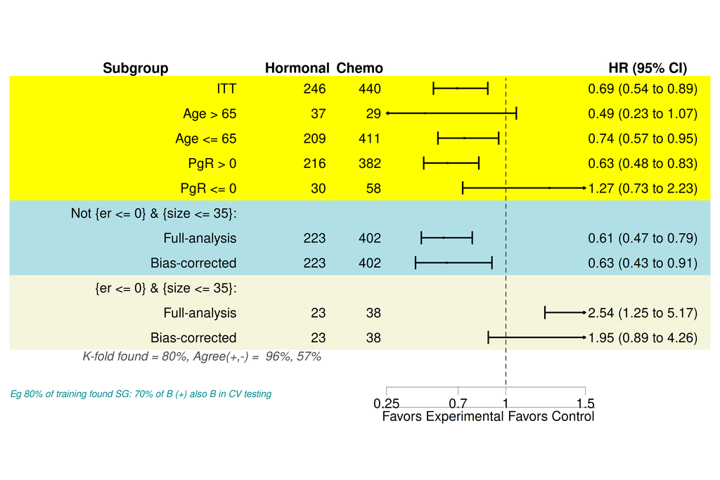

Subgroup forest plot (Cox PH analysis)

```r
render_forestplot(result_cox)
```

### 5.6.1 KM Difference Plots: ITT and Subgroups

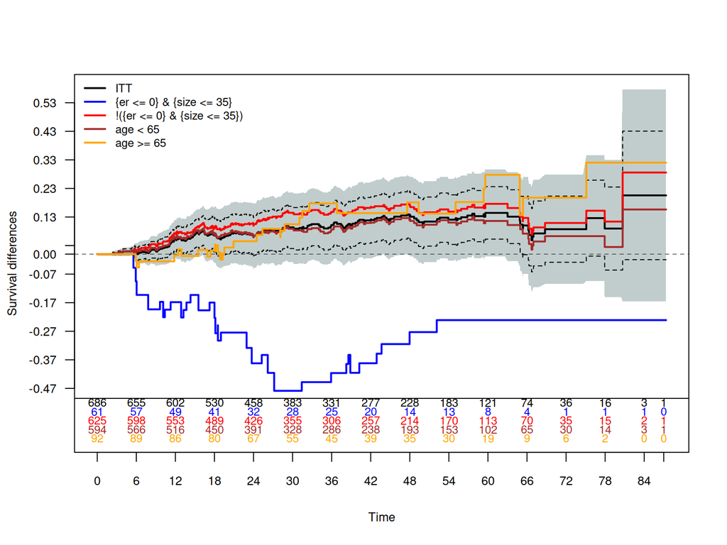

```r
ref_sgs <- list(
  age_young = list(subset_expr = "age < 65", color = "brown"),
  age_old = list(subset_expr = "age >= 65", color = "orange")
)

plot_km_band_forestsearch(
  df = df.analysis,
  fs.est = fs_cox,
  ref_subgroups = ref_sgs,
  outcome.name = cox_outcome.name,
  event.name = cox_event.name,
  treat.name = cox_treat.name,
  draws_band = 20
)
```

# 6 Part II: Poisson Rate Model Analysis

## 6.1 Rationale

The Poisson regression model with an offset for person-time provides an alternative to the Cox PH model for estimating treatment effects on the event rate scale (incidence rate ratio, IRR). Under an exponential survival assumption, the Poisson IRR is approximately equal to the Cox HR.

This section applies ForestSearch with `outcome_type = "count"` and `effect_measure = "IRR"` to the GBSG data, treating each patient’s binary event indicator (`status`) as a count (0 or 1) and `log(time_months)` as the offset. This is the standard piecewise exponential model approximation with a single interval per patient.

Comparing the Poisson and Cox analyses serves two purposes:

1. **Validation**: If both models identify the same subgroup with similar effect sizes, this strengthens confidence in the findings.
2. **GLM pipeline verification**: Demonstrates that the ForestSearch GLM extension produces coherent results on real clinical trial data.

## 6.2 ITT Poisson Model

```r
# Verify the Poisson approximation at the ITT level
cox_itt <- coxph(
  Surv(time_months, status) ~ hormon,
  data = df.analysis
)
pois_itt <- glm(
  status ~ hormon,
  family = poisson(),
  offset = log(pmax(time_months, 1e-6)),
  data = df.analysis
)

cat("ITT Cox  HR:      ", sprintf("%.4f", exp(coef(cox_itt))), "\n")
```

```
#> ITT Cox  HR:       0.6949
```

```r
cat("ITT Poisson IRR:  ", sprintf("%.4f", exp(coef(pois_itt)[["hormon"]])), "\n")
```

```
#> ITT Poisson IRR:   0.7007
```

```r
cat("Absolute diff:    ",
    sprintf("%.4f", abs(exp(coef(cox_itt)) - exp(coef(pois_itt)[["hormon"]]))),
    "\n")
```

```
#> Absolute diff:     0.0058
```

## 6.3 Running ForestSearch (Poisson)

The Poisson analysis uses `outcome_type = "count"` with `effect_measure = "IRR"` and `offset.name = "time_months"`. Screening and consistency thresholds are set identically to the Cox analysis so that any differences in results reflect the model, not tuning.

```r
t0 <- proc.time()

fs_pois <- forestsearch(
  df.analysis,
  confounders.name = confounders.name,
  outcome.name = pois_outcome.name,
  treat.name = pois_treat.name,
  id.name = id.name,
  # GLM parameters (event.name is not needed for count outcomes;
  # forestsearch() handles this internally)
  outcome_type = "count",
  effect_measure = pois_effect_measure,
  offset.name = pois_offset.name,
  # Threshold parameters (same as Cox for comparability)
  hr.threshold = fs_hr.threshold,
  hr.consistency = fs_hr.consistency,
  pconsistency.threshold = fs_pconsistency.threshold,
  stop_threshold = fs_stop_threshold,
  # Search configuration
  sg_focus = "hr",
  max_subgroups_search = fs_max_subgroups_search,
  use_twostage = TRUE,
  # Factor selection
  use_grf = TRUE,
  return_selected_cuts_only = TRUE,
  use_lasso = TRUE,
  cut_type = "default",
  # Subgroup constraints
  maxk = fs_maxk,
  n.min = fs_n.min,
  d0.min = fs_d0.min,
  d1.min = fs_d1.min,
  # Consistency evaluation
  fs.splits = fs_splits,
  # Parallel processing
  parallel_args = list(
    plan = "multisession",
    workers = n_cores,
    show_message = TRUE
  ),
  # Output options
  showten_subgroups = TRUE,
  details = TRUE,
  plot.sg = FALSE,   # KM plots not applicable; use plot_sg_glm_outcomes()
  vi.grf.min = grf_vi_min,
  tune_grf = grf_tune
)
```

```
#>
#> [forestsearch] Subgroup Identification Configuration
#>   Outcome type:   count
#>   Effect measure: IRR (Incidence Rate Ratio)
#>   Scale:          log (ratio)
#>
#>   Screening:      IRR >= 1.25 (log: 0.2231)
#>   Consistency:    IRR >= 1.00 (log: 0.0000)
#>   Consistency rate threshold: 80%
#>
#>   Interpretation:
#>     Candidates: subgroup IRR >= 1.25
#>     Splits:     each split IRR >= 1.00
```

```
#>   Search Alignment Diagnostic
```

```
#>
#>   Outcome:    status (count)
```

```
#>   Offset:     time_months
```

```
#>   Treatment:  hormon
```

```
#>   Measure:    Incidence Rate Ratio (IRR)
```

```
#>
#>   ForestSearch searches for:
#>     Subgroups where hormon increases the event rate with offset = log(time_months)
#>     (IRR >= threshold)
```

```
#>
#>   Thresholds:
#>     Screening: IRR >= 1.250 in the candidate subgroup
#>     Consistency: IRR >= 1.000 in each bootstrap split
```

```
#>
#>   Variable screening:
```

```
#>     LASSO: LASSO screening uses glmnet with family = "poisson".
#>     Variables with non-zero coefficients are retained.
```

```
#>     GRF:   GRF sees log(status + 0.5) (variance-stabilising transform).
#>     Variable importance identifies covariates with
#>     heterogeneous treatment effects on the count scale.
```

```
#>
#>   No alignment concerns detected.
```

```
#> GRF subgroup: age <= 50 & age <= 42 & size <= 39
#> GRF cuts identified: 3
#>   Cuts: age <= 50, age <= 42, size <= 39
#> Cox-LASSO selected: 5 of 8 candidate factors
#>   Omitted: age, meno, er
#> Candidate factors: 16
#>  [1] "age <= 50"    "age <= 42"    "size <= 39"   "size <= 29.3" "size <= 25"
#>  [6] "size <= 20"   "size <= 35"   "nodes <= 5"   "nodes <= 3"   "nodes <= 1"
#> [11] "nodes <= 7"   "pgr <= 110"   "pgr <= 32.5"  "pgr <= 7"     "pgr <= 131.8"
#> [16] "grade3"
#> Number of possible configurations (<= maxk): maxk = 2 , # combinations = 528
#> Events criteria: control >= 12 , treatment >= 12
#> Sample size criteria: n >= 60
#> Subgroup search completed in 0.02 minutes
#>
#> --- Filtering Summary ---
#>   Combinations evaluated: 528
#>   Passed variance check: 489
#>   Passed prevalence (>= 0.025 ): 489
#>   Passed redundancy check: 466
#>   Passed event counts (d0>= 12 , d1>= 12 ): 436
#>   Passed sample size (n>= 60 ): 405
#>   Cox model fit successfully: 405
#>   Passed HR threshold (>= 0.2231436 ): 5
#> -------------------------
#>
#> Found 5 subgroup candidate(s)
#> # of candidate subgroups (meeting all criteria) = 5
#> # of unique initial candidates: 5
#> # Restricting to top stop_Kgroups = 3
#> # of candidates to evaluate: 3
#> # Early stop threshold: 0.8
#>
#> ================================================================================
#> TOP 3 CANDIDATE SUBGROUPS FOR CONSISTENCY EVALUATION
#> Sorted by: hr
#> ================================================================================
#>
#> Rank   IRR       N       Events  K    Subgroup Definition
#> --------------------------------------------------------------------------------
#> 1      1.639     72      72      2    {pgr <= 7} & {grade3}
#> 2      1.629     71      71      2    {age <= 50} & {pgr <= 7}
#> 3      1.350     71      71      2    {nodes <= 5} & !{size <= 35}
#> --------------------------------------------------------------------------------
```

```
#> Parallel plan: multisession with 120 workers.
```

```
#> Parallel config: workers = 120 , batch_size = 1
#> Batch 1 / 3 : candidates 1 - 1
#>
#> ==================================================
#> EARLY STOP TRIGGERED (batch 1 )
#>   Candidate: 1 of 3
#>   Pcons: 0.81 >= 0.8
#> ==================================================
#>
#> Evaluated 1 of 3 candidates (early stop)
#> 1 subgroups passed consistency threshold
#> SG focus = hr
#> Seconds and minutes forestsearch overall = 10.142 0.169
#> Consistency algorithm used: twostage
#> Subgroup identified: {pgr <= 7} & {grade3}
```

```r
plan("sequential")
timings$pois_fs <- (proc.time() - t0)["elapsed"]

cat("\nForestSearch (Poisson) completed in",
    round(timings$pois_fs, 1), "seconds\n")
```

```
#>
#> ForestSearch (Poisson) completed in 10.2 seconds
```

## 6.4 Poisson Results

### 6.4.1 Identified Subgroups

```r
pois_tabs <- sg_tables(fs_pois, ndecimals = 3, which_df = "est")
pois_tabs$sg10_out
```

**Identified Subgroups**

Two-factor subgroups (maxk=2)

| Factor 1 | Factor 2 | N | n(C+T) | n<sub>1</sub> | IRR | P<sub>cons</sub> |
| --- | --- | --- | --- | --- | --- | --- |
| {pgr <= 7} | {grade3} | 72 | 72 | 21 | 1.639 | 0.810 |

**Search Configuration:** Single-factor candidates (L) = 32; Maximum combinations evaluated = 528; Search depth (maxk) = 2  
**Search Results:** Candidate subgroups found = 5; Maximum IRR estimate = 1.64  
**Note:** E<sub>1</sub> = events in treatment arm; P<sub>cons</sub> = consistency proportion

### 6.4.2 Treatment Effect Estimates

```r
pois_tabs$tab_estimates
```

**Treatment Effect Estimates**

Training data estimates

| Subgroup | n | n1 | Rate(C) | Rate(T) | IRR (95% CI) |
| --- | --- | --- | --- | --- | --- |
| ITT | 686 (100.0%) | 246 (35.9%) | 46.6% | 38.2% | 0.70 (0.55, 0.89) |
| Questionable<sup>1</sup> | 72 (10.5%) | 21 (29.2%) | 51.0% | 61.9% | 1.64 (0.81, 3.33) |
| Recommend | 614 (89.5%) | 225 (36.6%) | 46.0% | 36.0% | 0.65 (0.51, 0.84) |

<sup>1</sup> **Identified subgroup** : {pgr <= 7} & {grade3}

### 6.4.3 Identified Subgroup Definition

```r
cat("Identified subgroup (H):",
    paste(fs_pois$sg.harm, collapse = " & "), "\n")
```

```
#> Identified subgroup (H): {pgr <= 7} & {grade3}
```

```r
cat("Subgroup size:", sum(fs_pois$df.est$treat.recommend == 0),
    sprintf("(%.1f%% of ITT)\n",
            100 * mean(fs_pois$df.est$treat.recommend == 0)))
```

```
#> Subgroup size: 72 (10.5% of ITT)
```

### 6.4.4 Subgroup Event Rates

```r
pois_plot <- plot_sg_glm_outcomes(
  fs.est = fs_pois,
  outcome.name = pois_outcome.name,
  treat.name = pois_treat.name,
  offset.name = pois_offset.name,
  effect_measure = pois_effect_measure,
  outcome_type = "count",
  E.name = "Hormonal",
  C.name = "Chemo",
  show_itt = TRUE,
  show_effect = TRUE,
  verbose = TRUE
)
```

[output not shown]

```
#> ℹ Adding new coordinate system, which will replace the existing one.
```

```
#> Figure note: Identified subgroup (H): {pgr <= 7} & {grade3}. Bars show event rates per arm; error bars show 95 percent CI.
```

## 6.5 Poisson Bootstrap Bias Correction

```r
t0 <- proc.time()

fs_pois_bc <- forestsearch_bootstrap_dofuture(
  fs.est = fs_pois,
  nb_boots = NB,
  show_three = FALSE,
  details = FALSE,
  parallel_args = list(
    plan = "multisession",
    workers = n_cores,
    show_message = TRUE
  )
)
```

```
#> Bootstrap parallel config: Using user-provided settings
```

```
#> System max cores available: 128
```

```
#> Bootstrap will use: 120 workers with 'multisession' plan
```

```
#> Parallel plan: multisession with 120 workers.
```

```
#> Bootstrap iteration 1/1000
```

```
#> Bootstrap iteration 10/1000
```

```
#> Bootstrap iteration 50/1000
```

```
#> Bootstrap iteration 100/1000
```

```
#> Bootstrap iteration 250/1000
```

```
#> Bootstrap iteration 500/1000
```

```
#> Bootstrap iteration 750/1000
```

```
#> Bootstrap iteration 1000/1000
```

```r
plan("sequential")
timings$pois_bootstrap <- (proc.time() - t0)["elapsed"]

cat("\nPoisson bootstrap completed in",
    round(timings$pois_bootstrap / 60, 1), "minutes\n")
```

```
#>
#> Poisson bootstrap completed in 4.9 minutes
```

### 6.5.1 Bootstrap Summary

```r
pois_summaries <- summarize_bootstrap_results(
  sgharm = fs_pois$sg.harm,
  boot_results = fs_pois_bc,
  create_plots = TRUE,
  est.scale = "hr"   # IRR is on the same ratio scale as HR
)
```

```
#>
#> ===============================================================
#>            BOOTSTRAP ANALYSIS SUMMARY
#> ===============================================================
#>
#> IDENTIFIED SUBGROUP:
#> -------------------------------------------------------------
#>   H: {pgr <= 7} & {grade3}
#>
#> BOOTSTRAP SUCCESS METRICS:
#> -------------------------------------------------------------
#>   Total iterations:              1000
#>   Successful subgroup ID:        974 (97.4%)
#>   Failed to find subgroup:       26 (2.6%)
#>
#> TIMING ANALYSIS:
#> -------------------------------------------------------------
#> Overall:
#>   Total bootstrap time:          4.83 minutes (0.08 hours)
#>   Average per iteration:         0.00 min (0.3 sec)
```

```r
pois_summaries$table
```

**Treatment Effect by Subgroup**

Bootstrap bias-corrected estimates (1000 iterations)

| Subgroup | Sample Size N | Sample Size N<sub>T</sub> | Event Rates Rate<sub>C</sub> | Event Rates Rate<sub>T</sub> | Treatment Effect IRR (95% CI)†<sup>1</sup> | Treatment Effect IRR‡ (95% CI)<sup>2</sup> |
| --- | --- | --- | --- | --- | --- | --- |
| Qstnbl<sup>3</sup> | 72 (10.5%) | 21 (29.2%) | 51.0% | 61.9% | 1.64 (0.81, 3.33) | 1.24 (0.55,2.83) |
| Recmnd | 614 (89.5%) | 225 (36.6%) | 46.0% | 36.0% | 0.65 (0.51, 0.84) | 0.68 (0.48,0.98) |

<sup>1</sup> **Unadjusted IRR**: GLM estimate with robust standard errors  
<sup>2</sup> **Bias-corrected IRR**: Bootstrap-adjusted estimate using infinitesimal jackknife method (1000 iterations). Corrects for optimism in subgroup selection.  
<sup>3</sup> **Identified subgroup**: {pgr <= 7} & {grade3}  
*Note*: Rate<sub>C</sub> = control arm event rate; Rate<sub>T</sub> = treatment arm event rate. Subgroup identified in 97.4% of bootstrap samples.

### 6.5.2 Bootstrap Diagnostics

```r
pois_summaries$diagnostics_table_gt
```

**Bootstrap Diagnostics Summary**

Analysis of 1000 bootstrap iterations

| Category | Metric | Value |
| --- | --- | --- |
| Success Rate | Total iterations | 1000 |
|  | Successful | 974 (97.4%) |
|  | Failed | 26 (2.6%) |
|  | Success rating | Excellent |
| Subgroup H (Questionable) | Observed IRR | 1.639 |
|  | Bias-corrected IRR | 1.245 |
|  | Bootstrap CV (%) | 220.2% |
|  | N estimates | 974 |
| Subgroup Hc (Recommend) | Observed IRR | 0.653 |
|  | Bias-corrected IRR | 0.682 |
|  | Bootstrap CV (%) | 55.4% |
|  | N estimates | 974 |

## 6.6 Poisson Cross-Validation

### 6.6.1 Out-of-Bag (N-Fold) Cross-Validation

```r
t0 <- proc.time()

fs_pois_OOB <- forestsearch_Kfold(
  fs.est = fs_pois,
  details = FALSE,
  Kfolds = round(nrow(df.analysis) / 100, 0),
  parallel_args = list(
    plan = "multisession",
    workers = n_cores,
    show_message = TRUE
  )
)
```

```
#> Parallel plan: multisession with 120 workers.
```

```r
plan("sequential")
timings$pois_oob <- (proc.time() - t0)["elapsed"]

cv_pois_out <- forestsearch_KfoldOut(
  res = fs_pois_OOB,
  details = FALSE,
  outall = TRUE
)

pois_cv_tables <- cv_summary_tables(cv_pois_out)
pois_cv_tables$combined_table
```

[output not shown]

```r
pois_cv_tables$metrics_table
```

**Cross-Validation Metrics**

Agreement and subgroup finding rates (%)

| Metric | Value (%) |
| --- | --- |
| Agreement |  |
| Sensitivity (H) | 43.1 |
| Sensitivity (Hc) | 89.6 |
| PPV (H) | 32.6 |
| PPV (Hc) | 93.1 |
| Finding |  |
| Any Found | 71.4 |
| Exact Match | 28.6 |
| At Least 1 | 42.9 |
| Cov1 Any | 42.9 |
| Cov2 Any | 28.6 |
| Cov1 & Cov2 | 28.6 |
| Cov1 Exact | 42.9 |
| Cov2 Exact | 28.6 |

## 6.7 Poisson Forest Plot

```r
result_pois <- plot_subgroup_results_forestplot(
  fs_results = list(
    fs.est = fs_pois,
    fs_bc = fs_pois_bc,
    fs_OOB = NULL,
    fs_kfold = NULL
  ),
  df_analysis = df.analysis,
  subgroup_list = subgroups,
  outcome.name = pois_outcome.name,
  event.name = pois_outcome.name,
  treat.name = pois_treat.name,
  E.name = "Hormonal",
  C.name = "Chemo",
  ci_column_spaces = 25,
  theme = my_theme
)
```

```
#> refline_lwd, refline_lty, refline_col will be deprecated, use refline_gp instead.
```

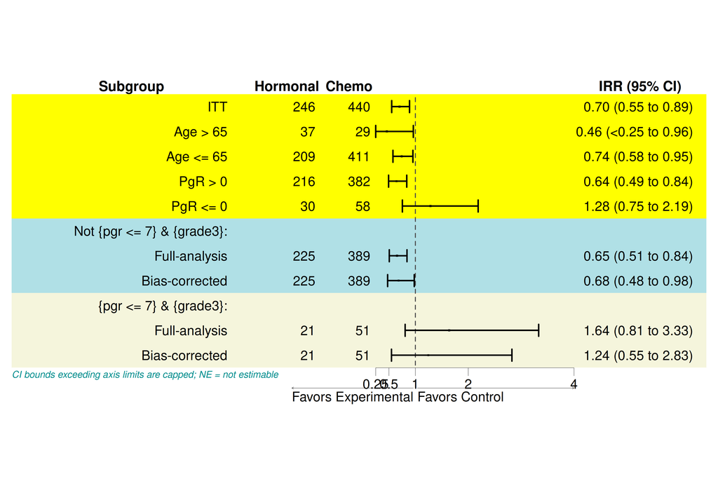

Subgroup forest plot (Poisson rate model)

```r
render_forestplot(result_pois)
```

# 7 Part III: Cox vs. Poisson Comparison

## 7.1 Subgroup Membership Concordance

```r
sg_compare <- compare_fs_subgroups(
  fs1    = fs_cox,
  fs2    = fs_pois,
  label1 = "Cox PH (HR)",
  label2 = "Poisson (IRR)",
  id.name = id.name,
  sg0_label = "H (Questionable)",
  sg1_label = "H\u1d9c (Recommend)",
  title  = "Subgroup Membership Concordance",
  font_size = 13
)

sg_compare$table
```

**Subgroup Membership Concordance**

Cox PH (HR) vs. Poisson (IRR)

| Cox PH (HR) | Poisson (IRR) H (Questionable) | Poisson (IRR) Hᶜ (Recommend) | Total |  |
| --- | --- | --- | --- | --- |
| H (Questionable) | 21 | 40 |  | 61 |
| Hᶜ (Recommend) | 51 | 574 | 625 |  |
| Total | 72 | 614 | 686 |  |

**Agreement:** 595 / 686 (86.7%) **Cohen’s κ:** 0.243 **Cox PH (HR) H:** {er <= 0} & {size <= 35} **Poisson (IRR) H:** {pgr <= 7} & {grade3}

```r
cat("Concordance statistics:\n")
```

```
#> Concordance statistics:
```

```r
cat("  Agreement:", sprintf("%.1f%%", 100 * sg_compare$concordance$agreement), "\n")
```

```
#>   Agreement: 86.7%
```

```r
cat("  Cohen's kappa:", sprintf("%.3f", sg_compare$concordance$kappa), "\n")
```

```
#>   Cohen's kappa: 0.243
```

```r
cat("  Concordant:", sg_compare$concordance$n_agree,
    "/ Discordant:", sg_compare$concordance$n_disagree,
    "/ Total:", sg_compare$concordance$n_total, "\n")
```

```
#>   Concordant: 595 / Discordant: 91 / Total: 686
```

## 7.2 Effect Estimate Comparison

```r
# Build comparison table
# Extract subgroup effect from the consistency result.
# Cox:     result$hr stores NATURAL-scale HR (no exponentiation needed)
# Poisson: result$hr stores LOG-scale IRR   (exponentiate for display)
.safe_effect <- function(fs_obj, idx = 1, exponentiate = FALSE) {
  tryCatch({
    val <- fs_obj$grp.consistency$out_sg$result$hr[idx]
    if (exponentiate) exp(val) else val
  }, error = function(e) NA_real_)
}

# Direct model fits for H and Hc (avoids ambiguity about stored scale)
cox_H_idx  <- fs_cox$df.est$treat.recommend == 0
pois_H_idx <- fs_pois$df.est$treat.recommend == 0

# Cox: H and Hc
cox_H_hr <- tryCatch(
  exp(coef(coxph(Surv(time_months, status) ~ hormon,
                 data = df.analysis[cox_H_idx, ]))),
  error = function(e) NA_real_
)
cox_Hc_hr <- tryCatch(
  exp(coef(coxph(Surv(time_months, status) ~ hormon,
                 data = df.analysis[!cox_H_idx, ]))),
  error = function(e) NA_real_
)

# Poisson: H and Hc
pois_H_irr <- tryCatch(
  exp(coef(glm(status ~ hormon, family = poisson(),
               offset = log(pmax(time_months, 1e-6)),
               data = df.analysis[pois_H_idx, ]))[["hormon"]]),
  error = function(e) NA_real_
)
pois_Hc_irr <- tryCatch(
  exp(coef(glm(status ~ hormon, family = poisson(),
               offset = log(pmax(time_months, 1e-6)),
               data = df.analysis[!pois_H_idx, ]))[["hormon"]]),
  error = function(e) NA_real_
)

compare_df <- data.frame(
  Estimand = c("ITT", "H (unadjusted)", "H^c (unadjusted)"),
  Cox_HR = c(exp(coef(cox_itt)), cox_H_hr, cox_Hc_hr),
  Poisson_IRR = c(exp(coef(pois_itt)[["hormon"]]), pois_H_irr, pois_Hc_irr)
)

compare_df$Absolute_Diff <- abs(compare_df$Cox_HR - compare_df$Poisson_IRR)

gt(compare_df) |>
  tab_header(
    title = "Cox HR vs. Poisson IRR Comparison",
    subtitle = "GBSG: ForestSearch-identified subgroups"
  ) |>
  fmt_number(columns = c(Cox_HR, Poisson_IRR, Absolute_Diff), decimals = 4) |>
  cols_label(
    Estimand = "Population",
    Cox_HR = "Cox HR",
    Poisson_IRR = "Poisson IRR",
    Absolute_Diff = "|Difference|"
  )
```

Cox HR vs. Poisson IRR Comparison

GBSG: ForestSearch-identified subgroups

| Population | Cox HR | Poisson IRR | \|Difference\| |
| --- | --- | --- | --- |
| ITT | 0.6949 | 0.7007 | 0.0058 |
| H (unadjusted) | 2.5369 | 1.6390 | 0.8979 |
| H^c (unadjusted) | 0.6079 | 0.6531 | 0.0451 |

## 7.3 Interpretation

Under the proportional hazards assumption with a single follow-up interval per patient, the Poisson rate model is the piecewise exponential approximation to Cox regression, and the IRR converges to the HR. Any differences between the two analyses arise from:

1. **GRF screening path**: The Cox analysis uses `causal_survival_forest`, while the Poisson analysis uses `causal_forest` on a variance-stabilised $\log(Y + 0.5)$ transform. Different screening can yield different candidate factors.
2. **Consistency evaluation**: The Cox path uses `coxph()` within each split-half; the Poisson path uses `glm(family = poisson(), offset = ...)`. Small-sample behaviour may differ.
3. **Threshold interpretation**: The screening threshold (1.25) and consistency threshold (1.0) are on the ratio scale for both HR and IRR, so they are directly comparable.

When the two analyses agree on subgroup membership, this provides **model-robustness evidence**: the finding is not an artifact of the Cox proportional hazards assumption.

# 8 Summary and Interpretation

## 8.1 Key Findings

```r
cat(strrep("=", 60), "\n")
cat("FORESTSEARCH ANALYSIS SUMMARY\n")
```

```
#> FORESTSEARCH ANALYSIS SUMMARY
```

```r
cat(strrep("=", 60), "\n\n")
cat("Dataset: GBSG (N =", nrow(df.analysis), ")\n")
```

```
#> Dataset: GBSG (N = 686 )
```

```r
cat("Outcome: Recurrence-free survival\n\n")
```

```
#> Outcome: Recurrence-free survival
```

```r
cat("ITT Analysis:\n")
```

```
#> ITT Analysis:
```

```r
cat("  Cox HR:      ", sprintf("%.4f", exp(coef(cox_itt))), "\n")
```

```
#>   Cox HR:       0.6949
```

```r
cat("  Poisson IRR: ", sprintf("%.4f", exp(coef(pois_itt)[["hormon"]])), "\n\n")
```

```
#>   Poisson IRR:  0.7007
```

```r
cat("Cox Identified Subgroup (H):\n")
```

```
#> Cox Identified Subgroup (H):
```

```r
cat("  Definition:", paste(fs_cox$sg.harm, collapse = " & "), "\n")
```

```
#>   Definition: {er <= 0} & {size <= 35}
```

```r
cat("  Size:", sum(fs_cox$df.est$treat.recommend == 0),
    sprintf("(%.1f%%)\n", 100 * mean(fs_cox$df.est$treat.recommend == 0)))
```

```
#>   Size: 61 (8.9%)
```

```r
cat("\nPoisson Identified Subgroup (H):\n")
```

```
#>
#> Poisson Identified Subgroup (H):
```

```r
cat("  Definition:", paste(fs_pois$sg.harm, collapse = " & "), "\n")
```

```
#>   Definition: {pgr <= 7} & {grade3}
```

```r
cat("  Size:", sum(fs_pois$df.est$treat.recommend == 0),
    sprintf("(%.1f%%)\n", 100 * mean(fs_pois$df.est$treat.recommend == 0)))
```

```
#>   Size: 72 (10.5%)
```

## 8.2 Clinical Interpretation

**Biological plausibility**: Tamoxifen is a selective estrogen receptor modulator. Its efficacy depends on ER expression. The finding that ER-negative patients may not benefit is consistent with:

- Mechanistic understanding of tamoxifen action
- Meta-analyses showing no tamoxifen benefit in ER-negative breast cancer
- Clinical guidelines recommending tamoxifen primarily for ER-positive tumors

**Caveats**:

1. This is an **exploratory** analysis requiring independent validation
2. The bias-corrected estimates have wider confidence intervals
3. Cross-validation metrics should be evaluated for algorithm stability

## 8.3 Computational Timing

```r
timings$total <- (proc.time() - t_vignette_start)["elapsed"]

timing_df <- data.frame(
  Analysis = c(
    "GRF Screening",
    "ForestSearch (Cox)", "Bootstrap (Cox)",
    "K-Fold CV (Cox)", "OOB CV (Cox)",
    "ForestSearch (Poisson)", "Bootstrap (Poisson)",
    "OOB CV (Poisson)",
    "Total"
  ),
  Seconds = c(
    timings$grf,
    timings$cox_fs, timings$cox_bootstrap,
    timings$cox_kfold, timings$cox_oob,
    timings$pois_fs, timings$pois_bootstrap,
    timings$pois_oob,
    timings$total
  )
)
timing_df$Minutes <- timing_df$Seconds / 60

gt(timing_df) |>
  tab_header(title = "Computational Timing") |>
  fmt_number(columns = c(Seconds, Minutes), decimals = 1) |>
  cols_label(
    Analysis = "Component",
    Seconds = "Time (sec)",
    Minutes = "Time (min)"
  )
```

Computational Timing

| Component | Time (sec) | Time (min) |
| --- | --- | --- |
| GRF Screening | 0.4 | 0.0 |
| ForestSearch (Cox) | 6.5 | 0.1 |
| Bootstrap (Cox) | 124.0 | 2.1 |
| K-Fold CV (Cox) | 51.1 | 0.9 |
| OOB CV (Cox) | 7.0 | 0.1 |
| ForestSearch (Poisson) | 10.2 | 0.2 |
| Bootstrap (Poisson) | 296.4 | 4.9 |
| OOB CV (Poisson) | 19.2 | 0.3 |
| Total | 522.1 | 8.7 |

# 9 References

León LF, Jemielita T, Guo Z, Marceau West R, Anderson KM (2024). “Exploratory subgroup identification in the heterogeneous Cox model: A relatively simple procedure.” *Statistics in Medicine*. DOI: 10.1002/sim.10163